# Explore_bikeshare_data

### Question 3

Which are the 20 most popular ending bike share locations in Washington?

```r
#package declarations
library(ggplot2)
library(dplyr)
library(forcats)

#assigning the Washington bikeshare dataset
wash = read.csv('washington.csv')
```

```r
#a glance through the dataset
head(wash)

#summary statistics
summary(wash)
```

[output not shown]

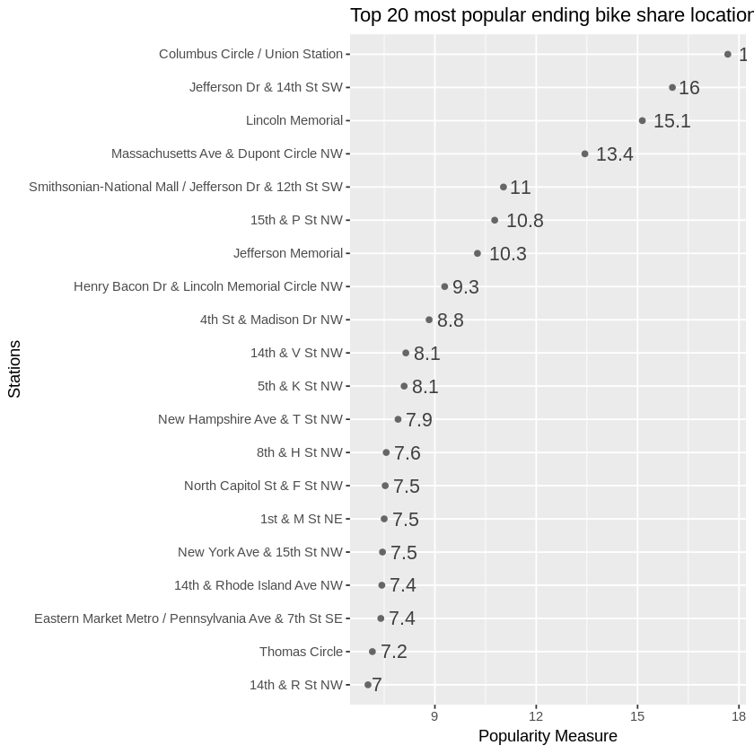

```r
#Data analysis using dplyr : dataset, top n(where n=20) and descending order arrangement
wash%>%
  group_by(End.Station) %>%
  tally() %>%
  top_n(20) %>%
  arrange(desc(n)) %>%
  mutate(n=n/100,End.Station=fct_reorder(End.Station,n,last)) %>%

#plotting using ggplot : dataset, aesthetics, axis labels and grouping and arranging by maximum End Stations

  ggplot()+
  geom_point(aes(y=End.Station, x=n), fill='gray10', col="gray40")+
  geom_text(aes(y=End.Station, x=n,label=round(n,1), hjust=-0.3), col="gray25", size=4.5)+
  labs(title="Top 20 most popular ending bike share locations",
       x="Popularity Measure",
       y="Stations"
)
```

This chart plots the top 20 most popular bike ending stations.

Post calculating the popularity measure which is nothing but a subsidized measure of the number of times an ending station appears in the dataset. This measure is used to plot against the various station names. This is an important asset in determing as to which station more focus and business can be expected and thereby improving overall efficiency.

## Finishing Up

> Congratulations! You have reached the end of the Explore Bikeshare Data Project. You should be very proud of all you have accomplished!

> **Tip**: Once you are satisfied with your work here, check over your report to make sure that it is satisfies all the areas of the [rubric](https://review.udacity.com/#!/rubrics/2508/view).

## Directions to Submit

> Before you submit your project, you need to create a .html or .pdf version of this notebook in the workspace here. To do that, run the code cell below. If it worked correctly, you should get a return code of 0, and you should see the generated .html file in the workspace directory (click on the orange Jupyter icon in the upper left).

> Alternatively, you can download this report as .html via the **File** > **Download as** submenu, and then manually upload it into the workspace directory by clicking on the orange Jupyter icon in the upper left, then using the Upload button.

> Once you've done this, you can submit your project by clicking on the "Submit Project" button in the lower right here. This will create and submit a zip file with this .ipynb doc and the .html or .pdf version you created. Congratulations!

```r
system('python -m nbconvert Explore_bikeshare_data.ipynb')
```